# Gut Content Analysis: Amundsen graphs

Jess Madden

2/19/2021

### Guts summary

| site | season | Stomachs processed | Total collected |
| --- | --- | --- | --- |
| Percos | Fall | 22 | 44 |
| Percos | Summer | 27 | 47 |
| R Beach | Fall | 11 | 105 |
| R Beach | Summer | 51 | 53 |
| Refugio | Fall | 7 | 38 |
| Refugio | Summer | 20 | 34 |

### Amundsen plots

Frequency of occurrence of prey i: %Fi = (Ni/N)*100 Prey specific abundance: %Pi = (sum(Si)/sum(Sti)*100)

Plot emerita

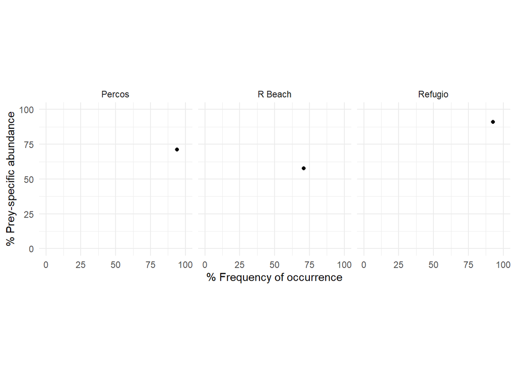

### Amundsen plots: Lifestage comparison

Frequency of occurrence of prey i: %Fi = (Ni/N)*100 Prey specific abundance: %Pi = (sum(Si)/sum(Sti)*100)

| site | season | lifestage | n |
| --- | --- | --- | --- |
| Percos | Fall | Adult | 18 |
| Percos | Fall | Juvenile | 4 |
| Percos | Summer | Adult | 20 |
| Percos | Summer | Juvenile | 7 |
| R Beach | Fall | Adult | 11 |
| R Beach | Summer | Adult | 18 |
| R Beach | Summer | Juvenile | 33 |
| Refugio | Fall | Juvenile | 7 |
| Refugio | Summer | Adult | 12 |
| Refugio | Summer | Juvenile | 8 |

Amundsen plots by lifestage

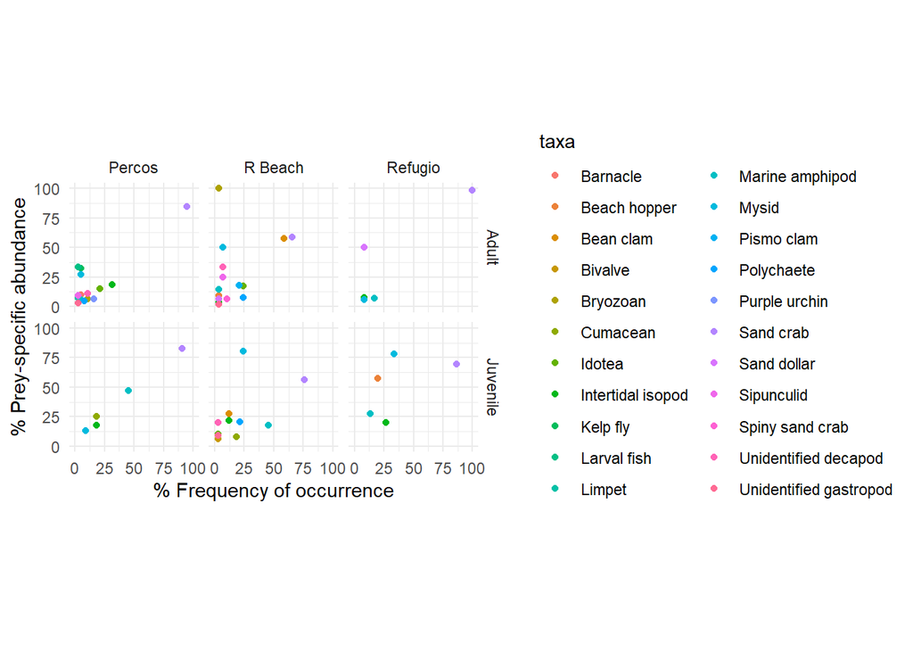

### Amundsen plots: Seasonal comparison

#### All sites compiled

Frequency of occurrence of prey i: %Fi = (Ni/N)*100

Prey specific abundance: %Pi = (sum(Si)/sum(Sti)*100)

Amundsen plots by season

| season | sample_size |
| --- | --- |
| Fall | 40 |
| Summer | 98 |

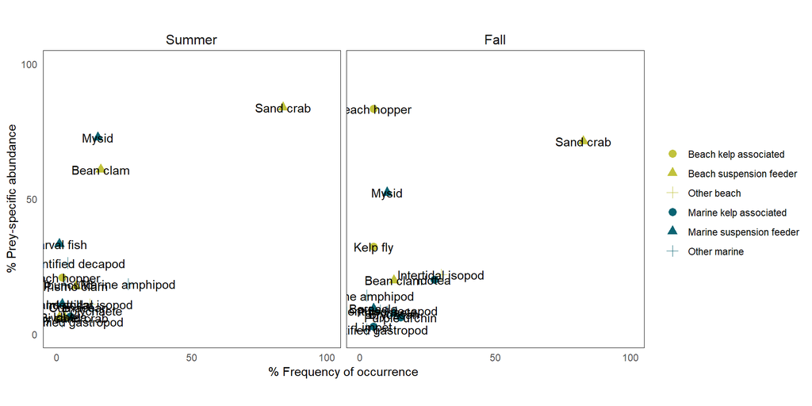

### Amundsen plots: R Beach tide comparison

Frequency of occurrence of prey i: %Fi = (Ni/N)*100

Prey specific abundance: %Pi = (sum(Si)/sum(Sti)*100)

| tide | sample_size |
| --- | --- |
| Neap | 21 |
| Spring | 30 |

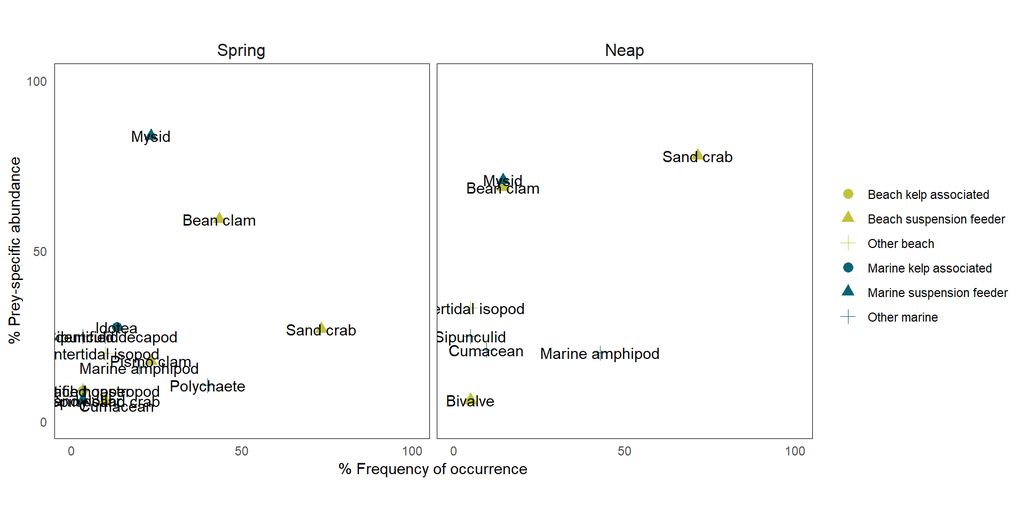

##### Tide comparison: gut richness

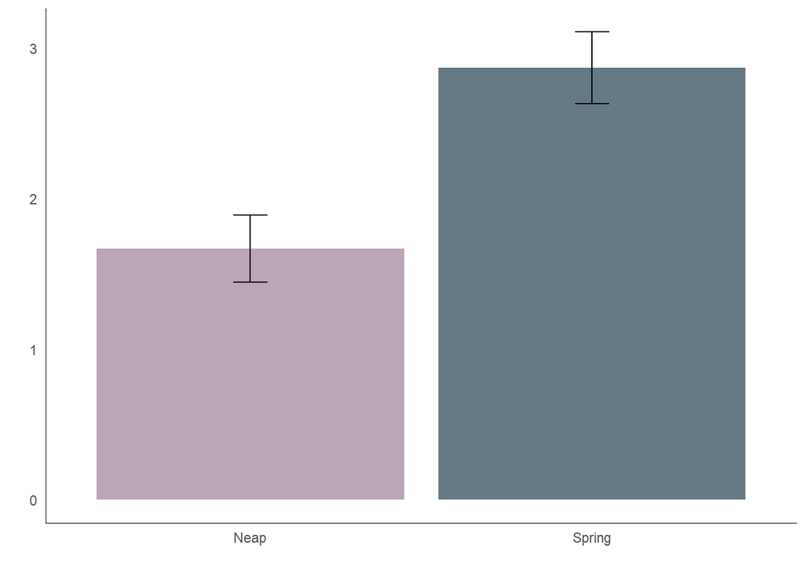

#### Amundsen plots: Site comparison

Figure out which taxa are dominant (average abundance >2%)

Frequency of occurrence of prey i: %Fi = (Ni/N)*100 Prey specific abundance: %Pi = (sum(Si)/sum(Sti)*100)

| site | n_distinct(fish_id) |
| --- | --- |
| Percos | 49 |
| R Beach | 62 |
| Refugio | 27 |

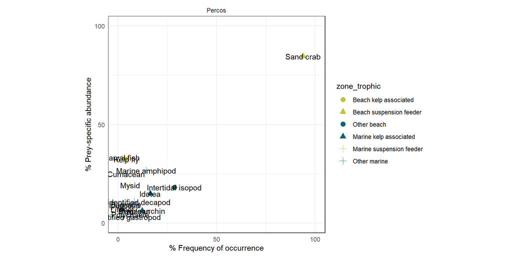

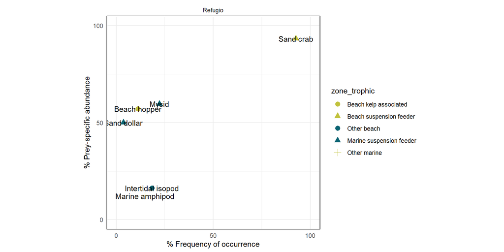

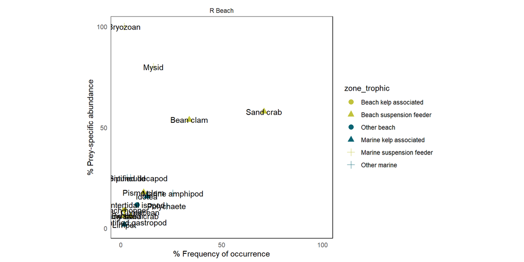

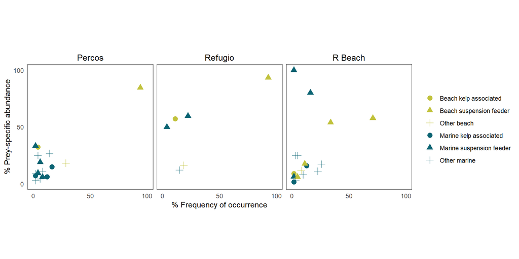

### SCA: Emerita

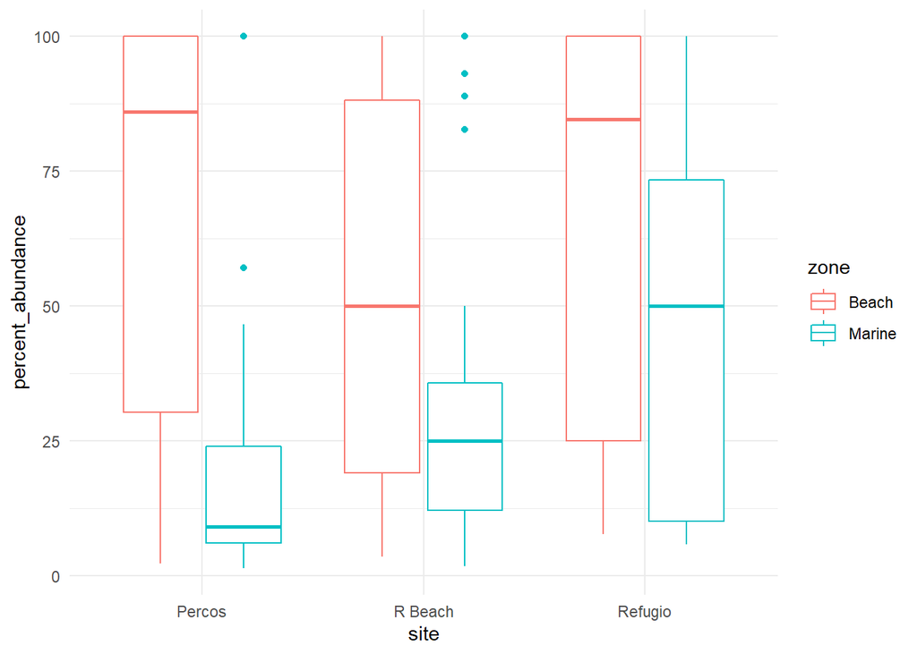

#### Emerita size vs. fish size

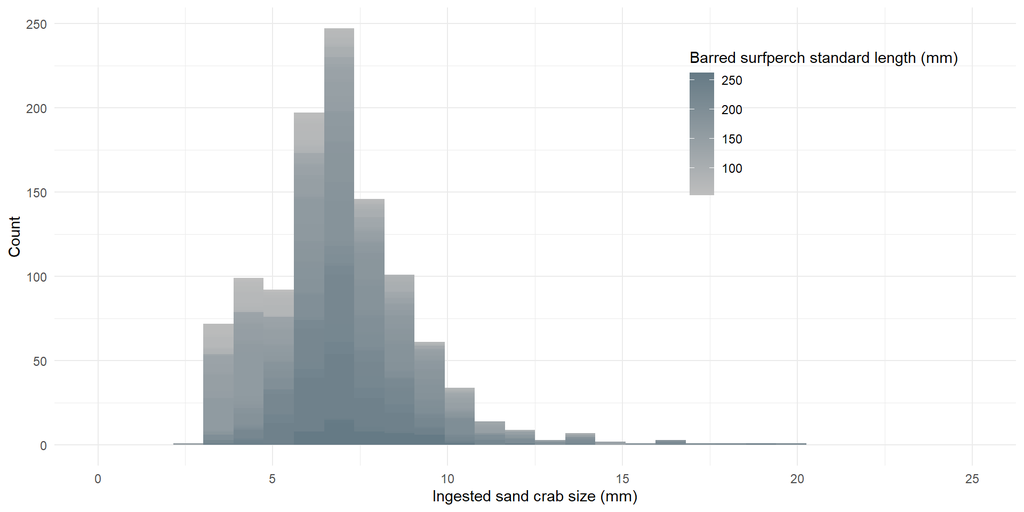

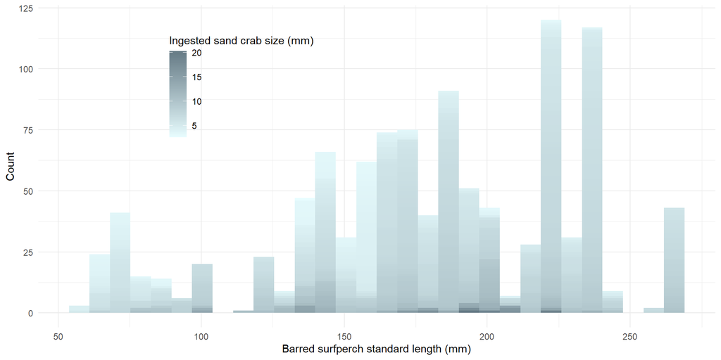

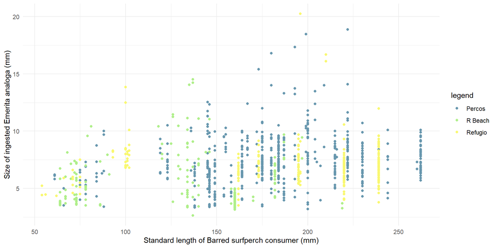

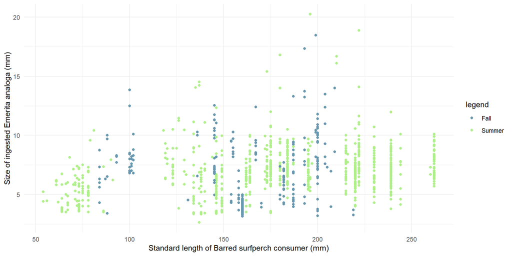

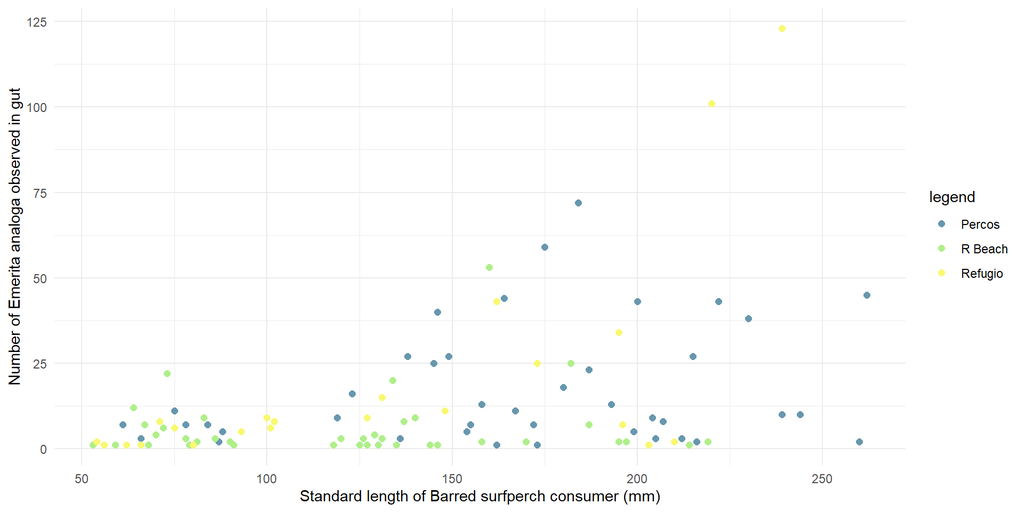

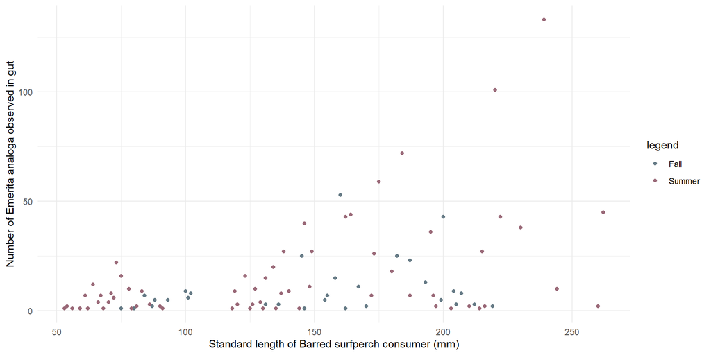

#### Emerita population data

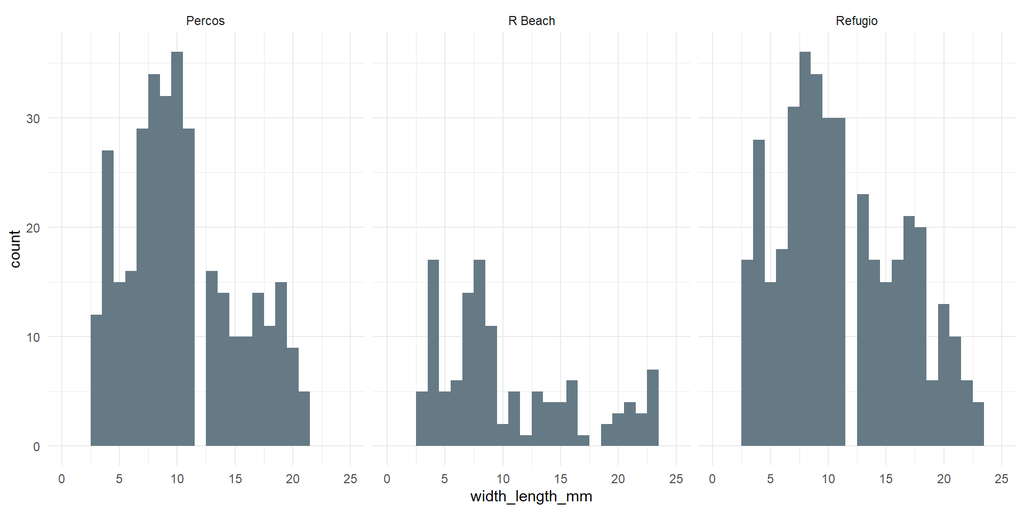

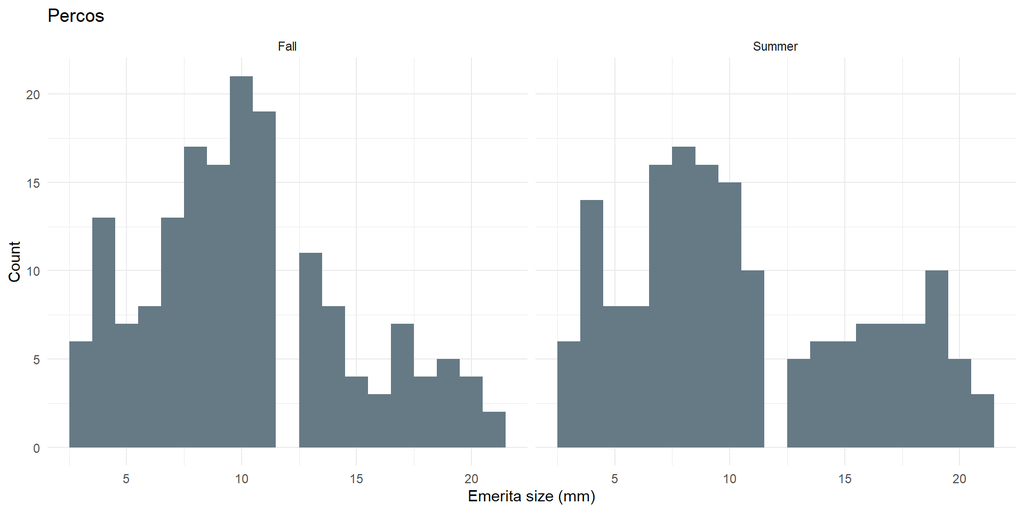

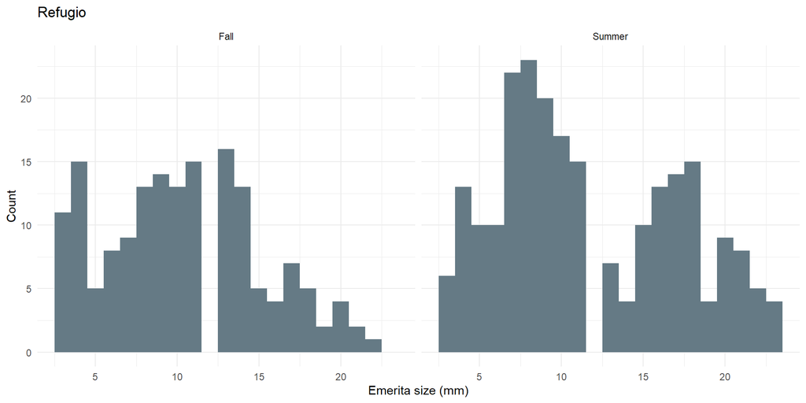

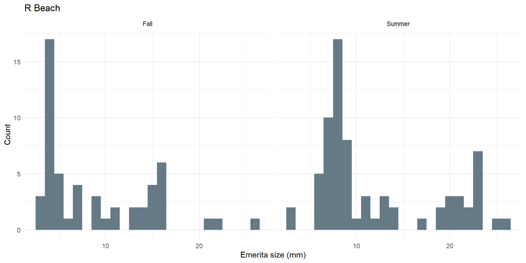

### Exploratory data analysis

#### Max crab size vs. fish size

OLS regression on max sand crab size in fish of each size

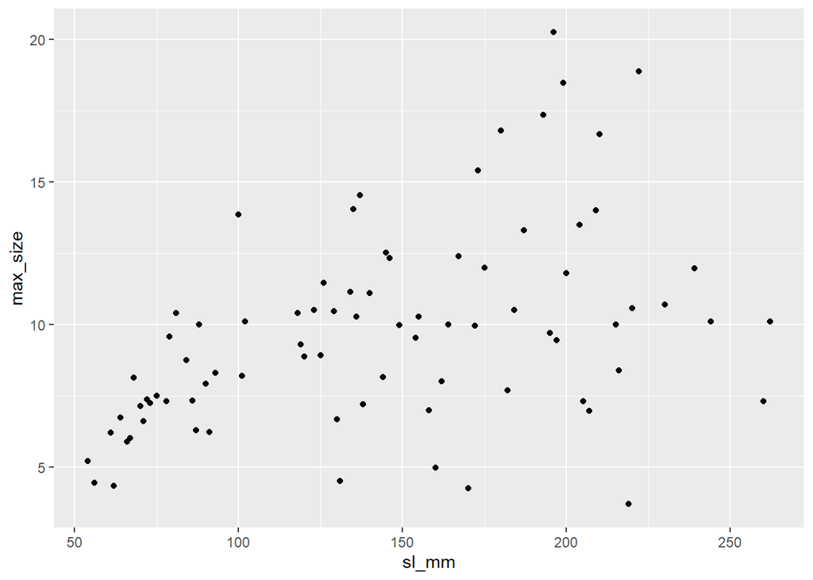

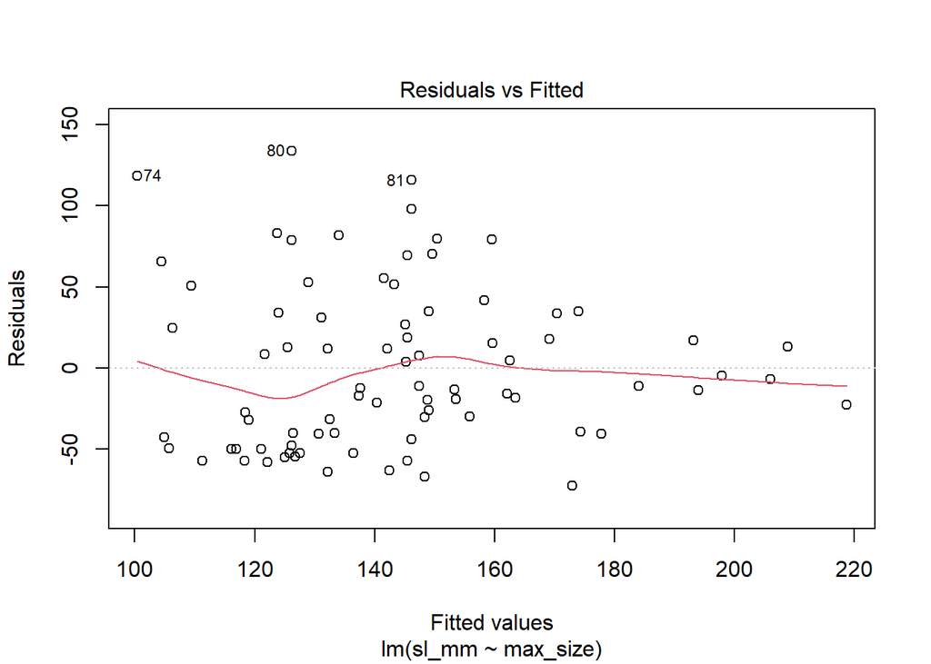

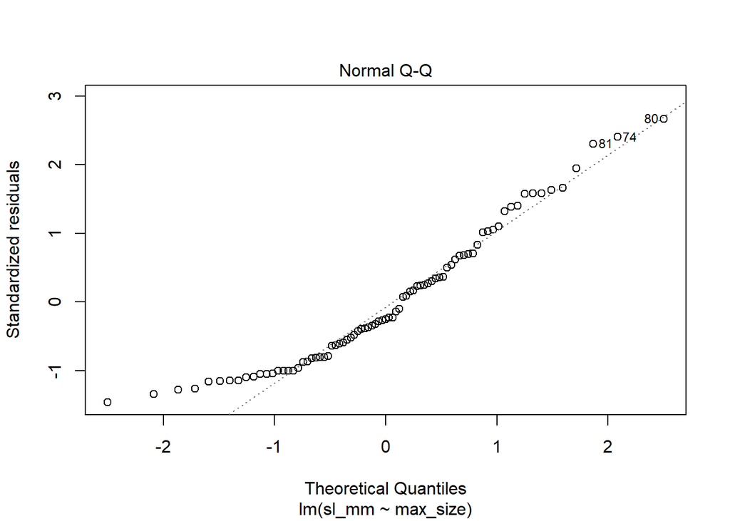

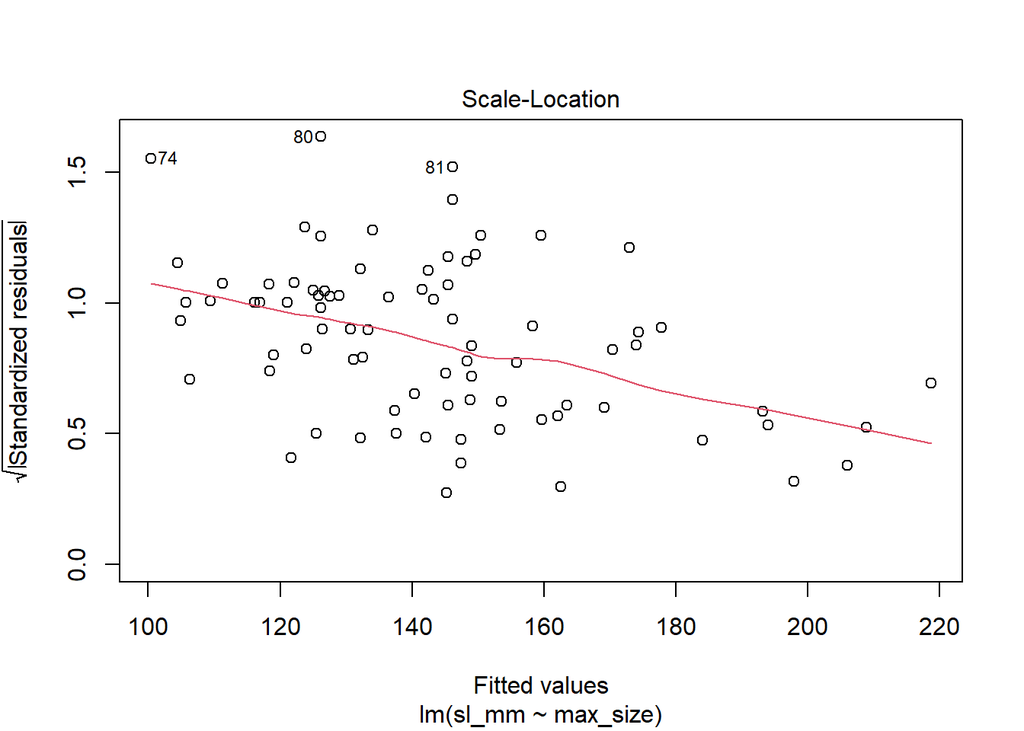

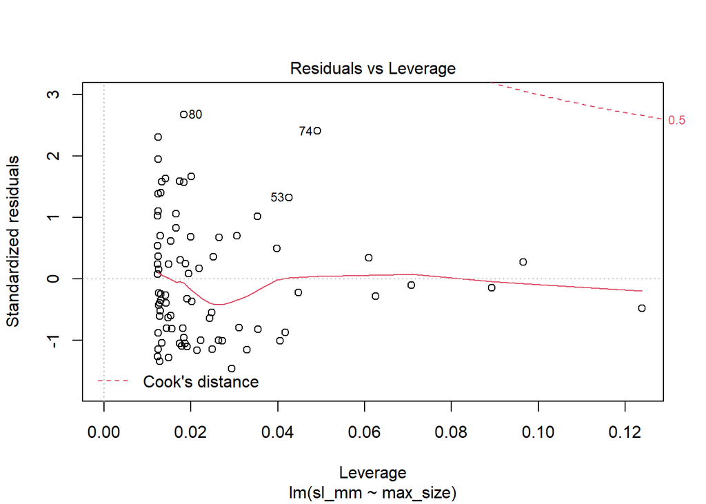

#### Gut content richness

- calculate index of diversity from each gut
- run an anova to compare by site

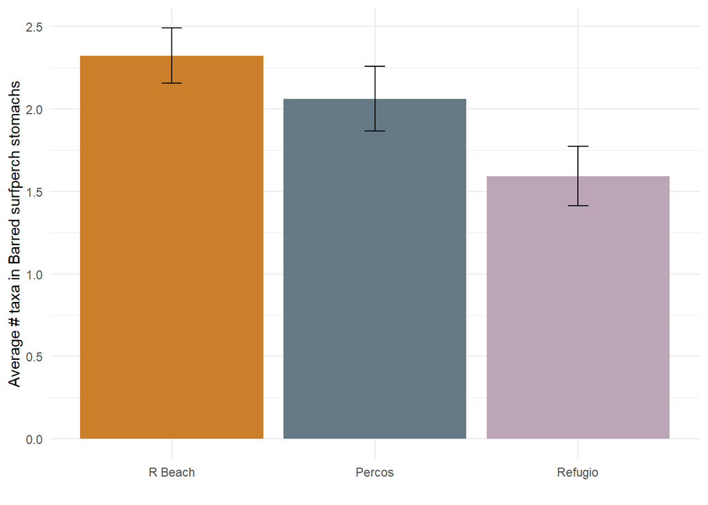

ANOVA assumptions

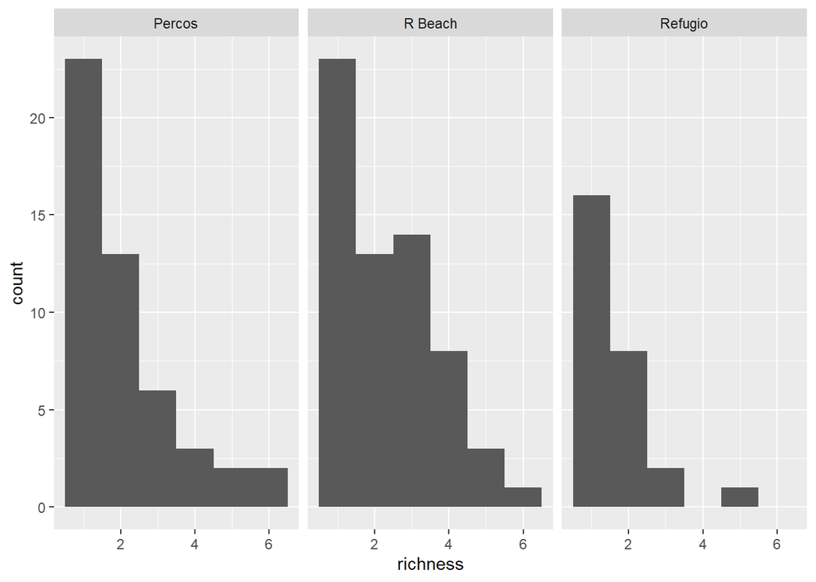

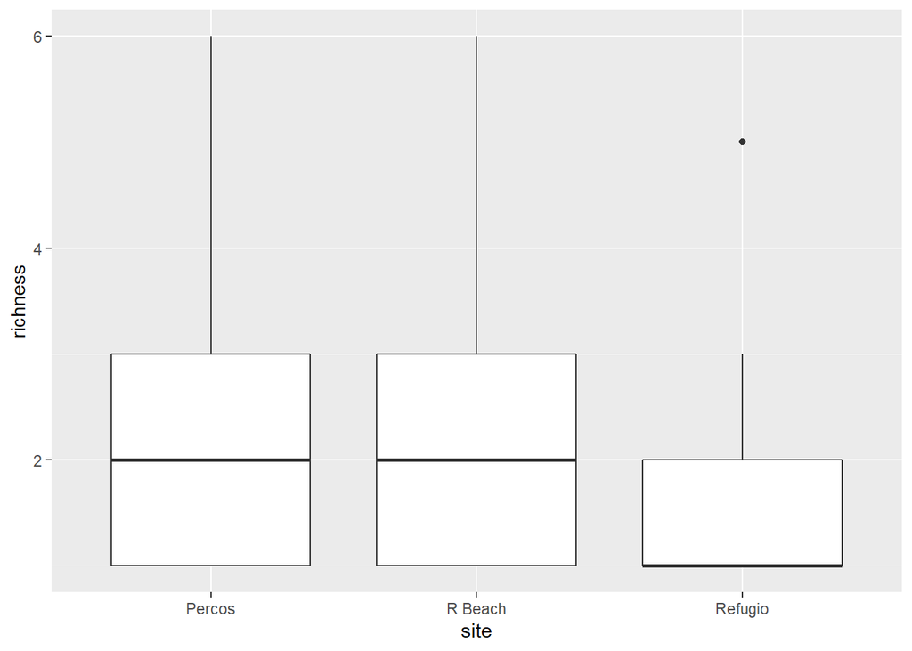

```
## Levene's Test for Homogeneity of Variance (center = median)
##        Df F value  Pr(>F)
## group   2  2.7852 0.06527 .
##       135
## ---
## Signif. codes:  0 '***' 0.001 '**' 0.01 '*' 0.05 '.' 0.1 ' ' 1
```

One-way ANOVA

```
##              Df Sum Sq Mean Sq F value Pr(>F)
## site          2  10.07   5.037   3.106  0.048 *
## Residuals   135 218.88   1.621
## ---
## Signif. codes:  0 '***' 0.001 '**' 0.01 '*' 0.05 '.' 0.1 ' ' 1
```

```
## Anova Table (Type II tests)
##
## Response: richness
##            Sum Sq  Df F value  Pr(>F)
## site       10.073   2  3.1064 0.04797 *
## Residuals 218.883 135
## ---
## Signif. codes:  0 '***' 0.001 '**' 0.01 '*' 0.05 '.' 0.1 ' ' 1
```

```
##   Tukey multiple comparisons of means
##     95% family-wise confidence level
##
## Fit: aov(formula = richness ~ site, data = gut_richness)
##
## $site
##                       diff        lwr         upr     p adj
## R Beach-Percos   0.2613562 -0.3154463  0.83815857 0.5319427
## Refugio-Percos  -0.4686319 -1.1918784  0.25461460 0.2776214
## Refugio-R Beach -0.7299881 -1.4257757 -0.03420036 0.0373592
```

#### Emerita vs Donax prey items

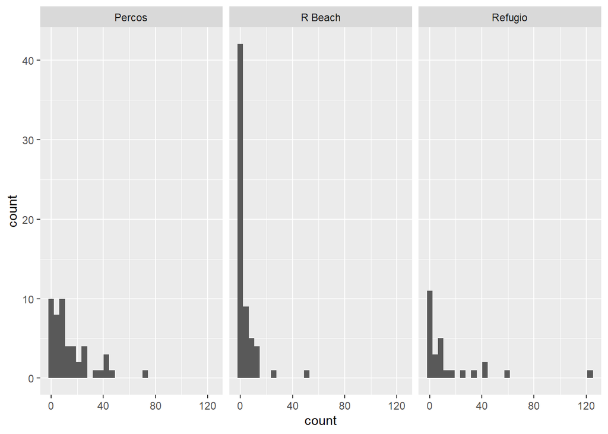

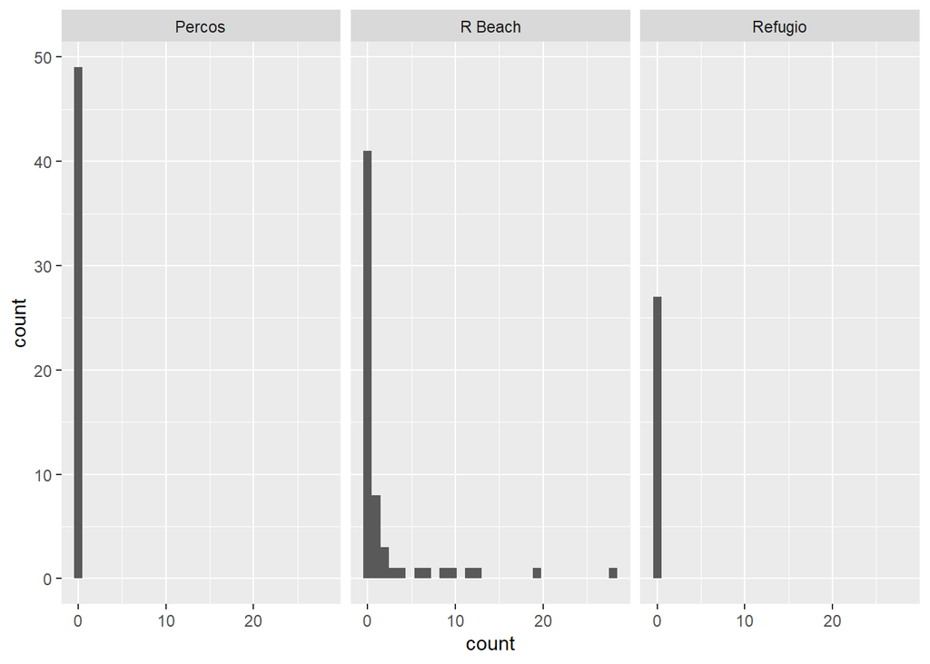